# 2. Define the Network Architecture

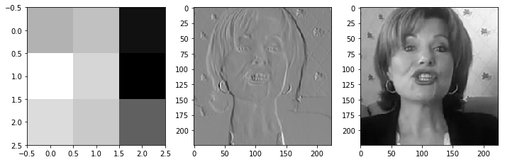

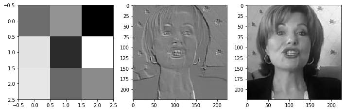

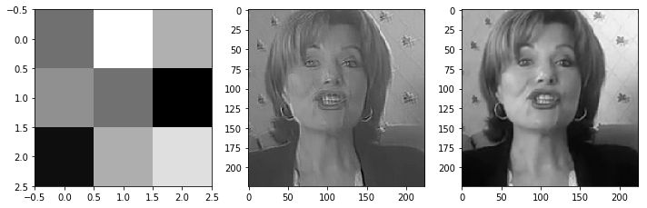

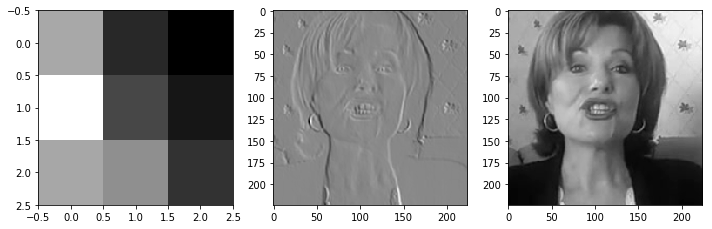

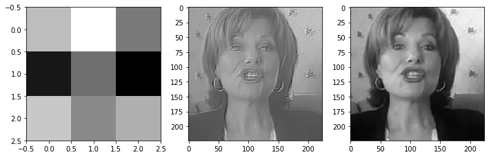

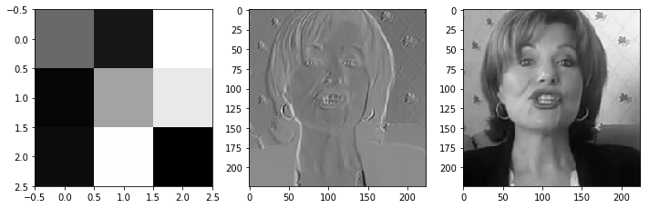

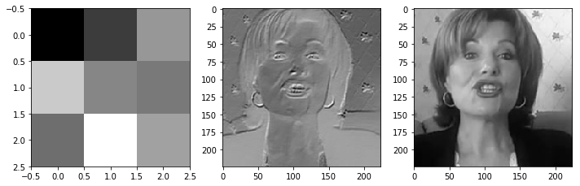

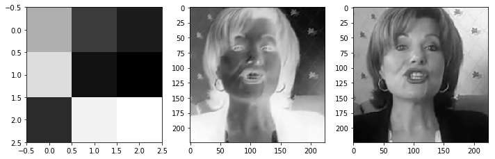

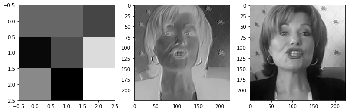

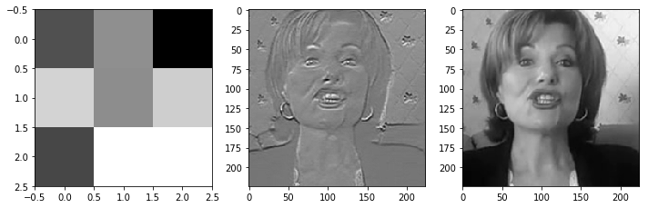

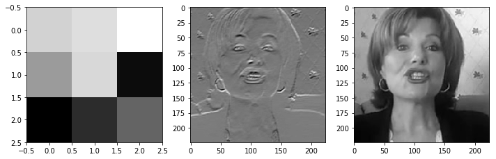

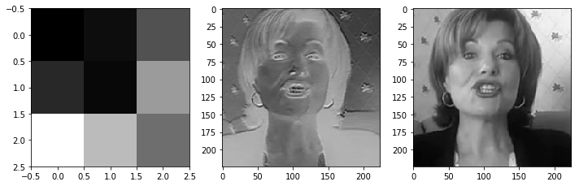

[20 more figures not shown]

```python
plt.figure(figsize=(20,10))
w = np.squeeze(w)
for i in range(w.shape[0]):
    f, (ax1, ax2, ax3) = plt.subplots(ncols=3, nrows=1, figsize=(10, 5))
    ax1.imshow(w[i], cmap='gray')
    filtered_image = cv2.filter2D(image, -1, w[i])
    ax2.imshow(filtered_image, cmap='gray')
    ax3.imshow(image, cmap='gray')
    plt.tight_layout()

plt.show()
```

### Question 4: Choose one filter from your trained CNN and apply it to a test image; what purpose do you think it plays? What kind of feature do you think it detects?

**Answer**: First CNN Layer usually detects simple edges like vertical pattern the later Complexity of CNN increases

## Moving on!

Now that you've defined and trained your model (and saved the best model), you are ready to move on to the last notebook, which combines a face detector with your saved model to create a facial keypoint detection system that can predict the keypoints on *any* face in an image!